# Project Python Foundations: FoodHub Data Analysis

### Context

The number of restaurants in New York is increasing day by day. Lots of students and busy professionals rely on those restaurants due to their hectic lifestyles. Online food delivery service is a great option for them. It provides them with good food from their favorite restaurants. A food aggregator company FoodHub offers access to multiple restaurants through a single smartphone app.

The app allows the restaurants to receive a direct online order from a customer. The app assigns a delivery person from the company to pick up the order after it is confirmed by the restaurant. The delivery person then uses the map to reach the restaurant and waits for the food package. Once the food package is handed over to the delivery person, he/she confirms the pick-up in the app and travels to the customer's location to deliver the food. The delivery person confirms the drop-off in the app after delivering the food package to the customer. The customer can rate the order in the app. The food aggregator earns money by collecting a fixed margin of the delivery order from the restaurants.

### Objective

The food aggregator company has stored the data of the different orders made by the registered customers in their online portal. They want to analyze the data to get a fair idea about the demand of different restaurants which will help them in enhancing their customer experience. Suppose you are hired as a Data Scientist in this company and the Data Science team has shared some of the key questions that need to be answered. Perform the data analysis to find answers to these questions that will help the company to improve the business.

### Data Description

The data contains the different data related to a food order. The detailed data dictionary is given below.

### Data Dictionary

- order_id: Unique ID of the order
- customer_id: ID of the customer who ordered the food
- restaurant_name: Name of the restaurant
- cuisine_type: Cuisine ordered by the customer
- cost_of_the_order: Cost of the order
- day_of_the_week: Indicates whether the order is placed on a weekday or weekend (The weekday is from Monday to Friday and the weekend is Saturday and Sunday)
- rating: Rating given by the customer out of 5
- food_preparation_time: Time (in minutes) taken by the restaurant to prepare the food. This is calculated by taking the difference between the timestamps of the restaurant's order confirmation and the delivery person's pick-up confirmation.
- delivery_time: Time (in minutes) taken by the delivery person to deliver the food package. This is calculated by taking the difference between the timestamps of the delivery person's pick-up confirmation and drop-off information

### Let us start by importing the required libraries

```python
# Installing the libraries with the specified version.
!pip install numpy==1.25.2 pandas==1.5.3 matplotlib==3.7.1 seaborn==0.13.1 -q --user
```

**Note**: *After running the above cell, kindly restart the notebook kernel and run all cells sequentially from the start again.*

```python
# import libraries for data manipulation
import numpy as np
import pandas as pd

# import libraries for data visualization
import matplotlib.pyplot as plt
import seaborn as sns
```

### Understanding the structure of the data

```python
# uncomment and run the following lines for Google Colab
# from google.colab import drive
# drive.mount('/content/drive')
```

```python
from IPython.display import display

# Define the correct path to the file on your local machine
file_path = r'C:\Users\Nobody\Downloads\school stuff\FoodHub Data Analysis\foodhub_order.csv'

# Load the CSV file into a DataFrame
df = pd.read_csv(file_path)

# Display the DataFrame
display(df)
```

|  | order_id | customer_id | restaurant_name | cuisine_type | cost_of_the_order | day_of_the_week | rating | food_preparation_time | delivery_time |
| --- | --- | --- | --- | --- | --- | --- | --- | --- | --- |
| 0 | 1477147 | 337525 | Hangawi | Korean | 30.75 | Weekend | Not given | 25 | 20 |
| 1 | 1477685 | 358141 | Blue Ribbon Sushi Izakaya | Japanese | 12.08 | Weekend | Not given | 25 | 23 |
| 2 | 1477070 | 66393 | Cafe Habana | Mexican | 12.23 | Weekday | 5 | 23 | 28 |
| 3 | 1477334 | 106968 | Blue Ribbon Fried Chicken | American | 29.20 | Weekend | 3 | 25 | 15 |
| 4 | 1478249 | 76942 | Dirty Bird to Go | American | 11.59 | Weekday | 4 | 25 | 24 |
| ... | ... | ... | ... | ... | ... | ... | ... | ... | ... |
| 1893 | 1476701 | 292602 | Chipotle Mexican Grill $1.99 Delivery | Mexican | 22.31 | Weekend | 5 | 31 | 17 |
| 1894 | 1477421 | 397537 | The Smile | American | 12.18 | Weekend | 5 | 31 | 19 |
| 1895 | 1477819 | 35309 | Blue Ribbon Sushi | Japanese | 25.22 | Weekday | Not given | 31 | 24 |
| 1896 | 1477513 | 64151 | Jack's Wife Freda | Mediterranean | 12.18 | Weekday | 5 | 23 | 31 |
| 1897 | 1478056 | 120353 | Blue Ribbon Sushi | Japanese | 19.45 | Weekend | Not given | 28 | 24 |

1898 rows × 9 columns

```python
# Display the first few rows of the DataFrame
display(df.head())
```

|  | order_id | customer_id | restaurant_name | cuisine_type | cost_of_the_order | day_of_the_week | rating | food_preparation_time | delivery_time |
| --- | --- | --- | --- | --- | --- | --- | --- | --- | --- |
| 0 | 1477147 | 337525 | Hangawi | Korean | 30.75 | Weekend | Not given | 25 | 20 |
| 1 | 1477685 | 358141 | Blue Ribbon Sushi Izakaya | Japanese | 12.08 | Weekend | Not given | 25 | 23 |
| 2 | 1477070 | 66393 | Cafe Habana | Mexican | 12.23 | Weekday | 5 | 23 | 28 |
| 3 | 1477334 | 106968 | Blue Ribbon Fried Chicken | American | 29.20 | Weekend | 3 | 25 | 15 |
| 4 | 1478249 | 76942 | Dirty Bird to Go | American | 11.59 | Weekday | 4 | 25 | 24 |

### **Question 1:** How many rows and columns are present in the data? [0.5 mark]

```python
from IPython.display import display

# Define the correct path to the file on your local machine
file_path = r'C:\Users\Nobody\Downloads\school stuff\FoodHub Data Analysis\foodhub_order.csv'

# Load the CSV file into a DataFrame
df = pd.read_csv(file_path)

# Display the DataFrame
display(df)
```

|  | order_id | customer_id | restaurant_name | cuisine_type | cost_of_the_order | day_of_the_week | rating | food_preparation_time | delivery_time |
| --- | --- | --- | --- | --- | --- | --- | --- | --- | --- |
| 0 | 1477147 | 337525 | Hangawi | Korean | 30.75 | Weekend | Not given | 25 | 20 |
| 1 | 1477685 | 358141 | Blue Ribbon Sushi Izakaya | Japanese | 12.08 | Weekend | Not given | 25 | 23 |
| 2 | 1477070 | 66393 | Cafe Habana | Mexican | 12.23 | Weekday | 5 | 23 | 28 |
| 3 | 1477334 | 106968 | Blue Ribbon Fried Chicken | American | 29.20 | Weekend | 3 | 25 | 15 |
| 4 | 1478249 | 76942 | Dirty Bird to Go | American | 11.59 | Weekday | 4 | 25 | 24 |
| ... | ... | ... | ... | ... | ... | ... | ... | ... | ... |
| 1893 | 1476701 | 292602 | Chipotle Mexican Grill $1.99 Delivery | Mexican | 22.31 | Weekend | 5 | 31 | 17 |
| 1894 | 1477421 | 397537 | The Smile | American | 12.18 | Weekend | 5 | 31 | 19 |
| 1895 | 1477819 | 35309 | Blue Ribbon Sushi | Japanese | 25.22 | Weekday | Not given | 31 | 24 |
| 1896 | 1477513 | 64151 | Jack's Wife Freda | Mediterranean | 12.18 | Weekday | 5 | 23 | 31 |
| 1897 | 1478056 | 120353 | Blue Ribbon Sushi | Japanese | 19.45 | Weekend | Not given | 28 | 24 |

1898 rows × 9 columns

#### Observations: we have a dataset with ratings with missing value , cusisine type , popularity, cost of order, day of the week orders, preparation and delievery time. most of the orders presented, are from 11 dollars to over 30 dollars.

### **Question 2:** What are the datatypes of the different columns in the dataset? (The info() function can be used) [0.5 mark]

```python
# Get the number of rows and columns in the DataFrame
rows, columns = df.shape

# Print the result
print(f"Number of rows: {rows}")
print(f"Number of columns: {columns}")

df.info()
```

```
Number of rows: 1898
Number of columns: 9
<class 'pandas.core.frame.DataFrame'>
RangeIndex: 1898 entries, 0 to 1897
Data columns (total 9 columns):
 #   Column                 Non-Null Count  Dtype
---  ------                 --------------  -----
 0   order_id               1898 non-null   int64
 1   customer_id            1898 non-null   int64
 2   restaurant_name        1898 non-null   object
 3   cuisine_type           1898 non-null   object
 4   cost_of_the_order      1898 non-null   float64
 5   day_of_the_week        1898 non-null   object
 6   rating                 1898 non-null   object
 7   food_preparation_time  1898 non-null   int64
 8   delivery_time          1898 non-null   int64
dtypes: float64(1), int64(4), object(4)
memory usage: 133.6+ KB
```

#### Observations: 1 float data type , 4 integers data type, and 4 objects data type

### **Question 3:** Are there any missing values in the data? If yes, treat them using an appropriate method. [1 mark]

```python
missingValues = df.isnull().sum()

print (missingValues)           #i DONT SEE ANY :) .....................................................Wishing you a joyous Diwali
```

```
order_id                 0
customer_id              0
restaurant_name          0
cuisine_type             0
cost_of_the_order        0
day_of_the_week          0
rating                   0
food_preparation_time    0
delivery_time            0
dtype: int64
```

### **Question 4:** Check the statistical summary of the data. What is the minimum, average, and maximum time it takes for food to be prepared once an order is placed? [2 marks]

```python
preparationSummary = df.get('food_preparation_time').describe()
print(preparationSummary)

#min = 20 , average = 27.37 , max 35.0
```

```
count    1898.000000
mean       27.371970
std         4.632481
min        20.000000
25%        23.000000
50%        27.000000
75%        31.000000
max        35.000000
Name: food_preparation_time, dtype: float64
```

#### Observations: most of the orders take from 27 minutes. if after 30 minutes its taking a longer than normal for prep time. have a notification to the customer letting them know what stage their orders are in.

### **Question 5:** How many orders are not rated? [1 mark]

```python
# check for missing or " NOt given Rating"

unratedOrders = df[df['rating'].isnull() | (df['rating'] == 'Not given')]

# count the number of unrated orders
unratedOrdersCount = unratedOrders.shape[0]

# print the result
print(f"Number of orders that are not rated: {unratedOrdersCount}")
#Number of orders that are not rated: 0 Write the code here
```

```
Number of orders that are not rated: 736
```

#### Observations: this dataset contains customers who didn't give the company a review. maybe a promotion to get additional feed back from orders.

### Exploratory Data Analysis (EDA)

### **Question 6:** Explore all the variables and provide observations on their distributions. (Generally, histograms, boxplots, countplots, etc. are used for univariate exploration.) [9 marks]

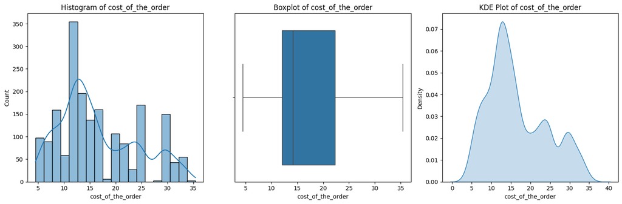

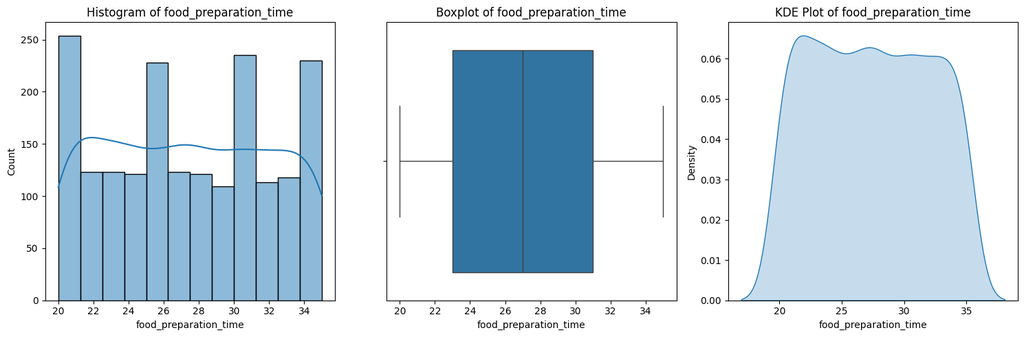

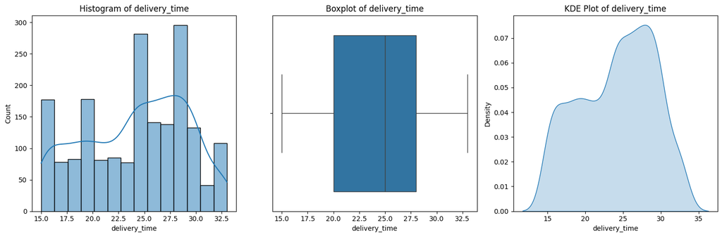

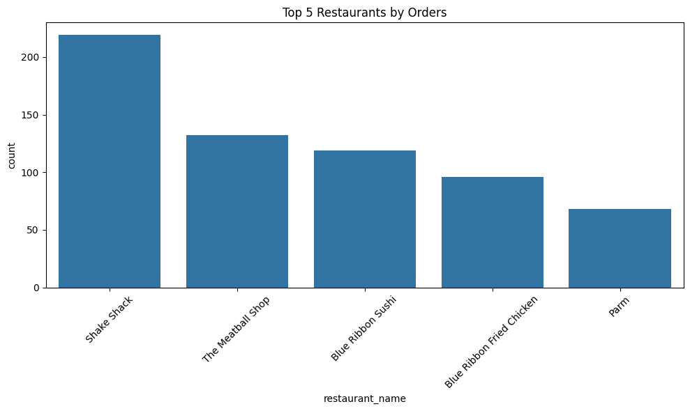

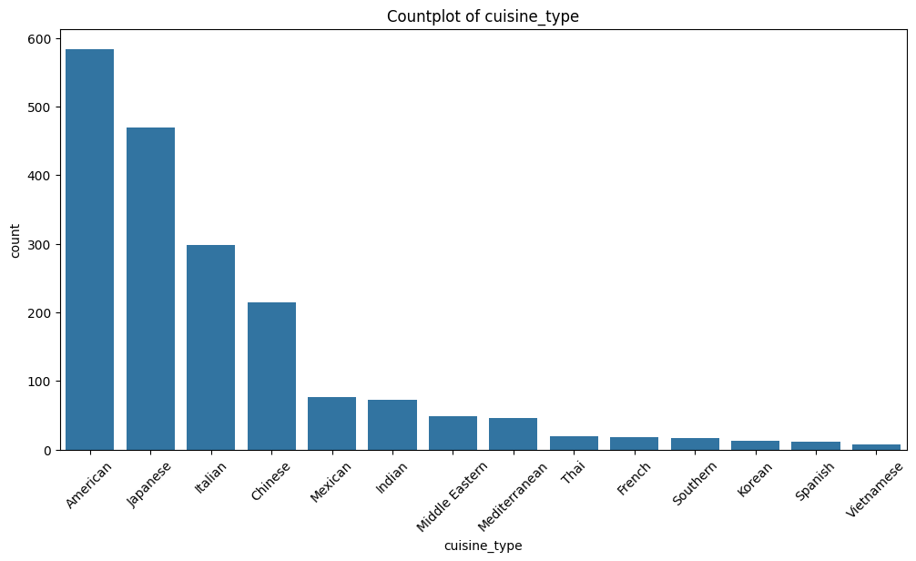

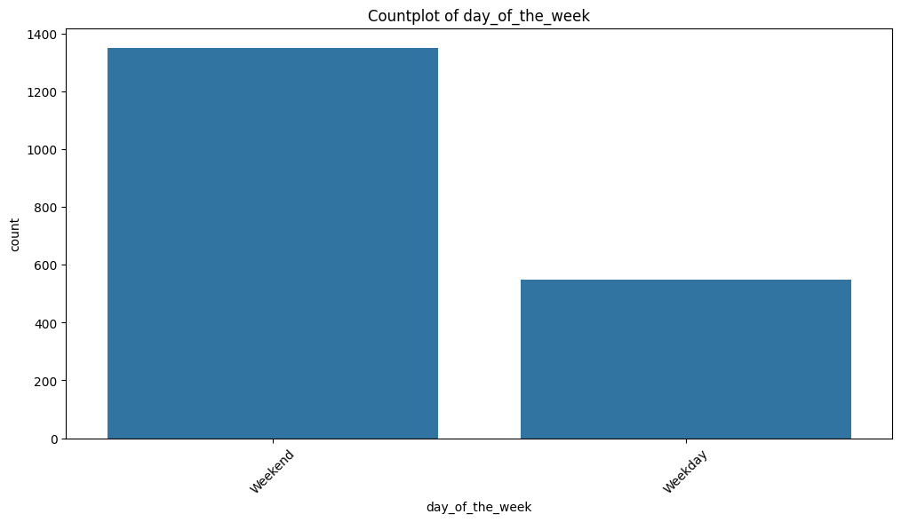

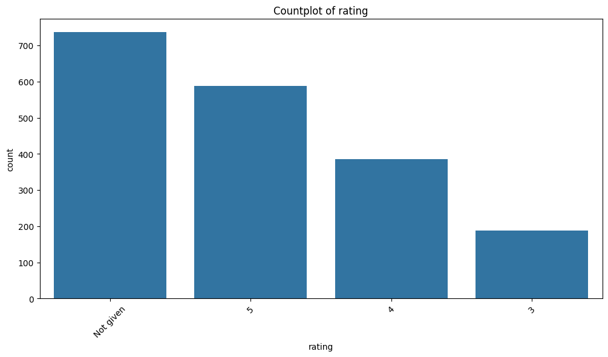

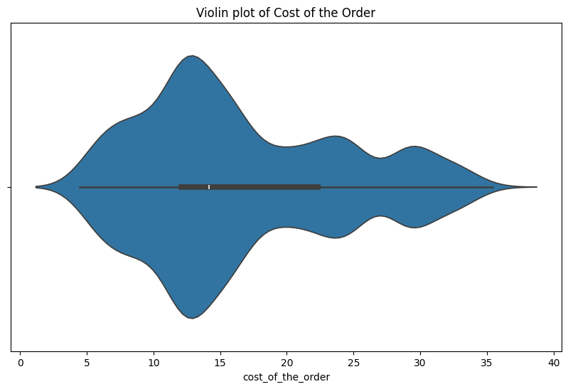

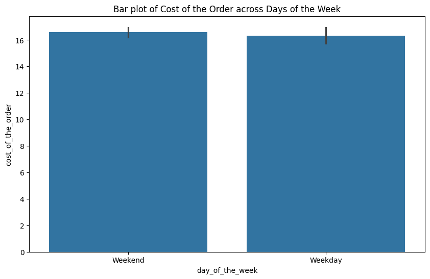

```python
import matplotlib.pyplot as plt
import seaborn as sns

# For Numerical Variables: Histogram, Boxplot, KDE plot
numericalCols = ['cost_of_the_order', 'food_preparation_time', 'delivery_time']

for col in numericalCols:
    plt.figure(figsize=(15, 5))

    # Histogram
    plt.subplot(1, 3, 1)
    sns.histplot(df[col], kde=True)
    plt.title(f'Histogram of {col}')

    # Boxplot
    plt.subplot(1, 3, 2)
    sns.boxplot(x=df[col])
    plt.title(f'Boxplot of {col}')

    # KDE plot
    plt.subplot(1, 3, 3)
    sns.kdeplot(df[col], fill=True)  # replace shade with fill
    plt.title(f'KDE Plot of {col}')

    plt.tight_layout()
    plt.show()

    # clean restaurant name column

df['restaurant_name'] = df['restaurant_name'].str.replace(r'[^\x00-\x7F]+', '',regex=True)

# for categorical variables: count plot (Limiit to Top 5 Restaurants)

# get the top 5 restaurants by number of order
top5Restaurants = df['restaurant_name'].value_counts().head(5).index

#plot only the top 5 restaurants
plt.figure(figsize = (10,6))
sns.countplot(x = 'restaurant_name', data = df[df['restaurant_name'].isin(top5Restaurants)],
               order = top5Restaurants)
plt.xticks(rotation = 45, fontsize = 10) # slightly rotate the labels for better readablity
plt.title('Top 5 Restaurants by Orders')
plt.tight_layout()
plt.show()


#For other categorical columns: cuisine_type, day_of_the_week, rating
categoricalCols = ['cuisine_type', 'day_of_the_week', 'rating']

for col in categoricalCols:
    plt.figure(figsize=(12, 6))
    sns.countplot(x=col, data=df, order=df[col].value_counts().index)
    plt.title(f'Countplot of {col}')
    plt.xticks(rotation = 45)
    plt.show()

# Violin plot to show the distribution of numerical variables
plt.figure(figsize=(10, 6))
sns.violinplot(x=df['cost_of_the_order'])
plt.title('Violin plot of Cost of the Order')
plt.show()

# Bar plot to see how the numerical variable (cost of the order) behaves across different categorical variables (day of the week)
plt.figure(figsize=(10, 6))
sns.barplot(x='day_of_the_week', y='cost_of_the_order', data=df)
plt.title('Bar plot of Cost of the Order across Days of the Week')
plt.show()
```

### **Question 7**: Which are the top 5 restaurants in terms of the number of orders received? [1 mark]

```python
# count the number of order for each restaurant
restaurantOrderCount = df['restaurant_name'].value_counts()

# Get the top 5 restaurants with the most orders
top5restaurants = restaurantOrderCount.head(5)

# display the result
print(top5restaurants)
#Shake Shack                  219
#The Meatball Shop            132
#Blue Ribbon Sushi            119
#Blue Ribbon Fried Chicken     96
#Parm                          68
#Name: restaurant_name, dtype: int64
```

```
Shake Shack                  219
The Meatball Shop            132
Blue Ribbon Sushi            119
Blue Ribbon Fried Chicken     96
Parm                          68
Name: restaurant_name, dtype: int64
```

#### Observations: orders from these restaurants take priority over others. be on time, and have everything the customer requested. give drivers a incetive to do their best when it comes to the top restaurants. maybe a bonus or gift card . Or the company can take a less percentage cut instead of the normal rate. we want to keep our biggest contributors happy .

### **Question 8**: Which is the most popular cuisine on weekends? [1 mark]

```python
# process the data to have only weekend orders
weekendOrders = df[df['day_of_the_week'] == 'Weekend']

# count weekend orders of each cuisine type
mostPopularCuisineWeekend = weekendOrders['cuisine_type'].value_counts().idxmax()

# display the most popular cuisine on the WEEKEND
print(f"THE MOST POPULAR CUISINE ON THE WEEKEND IS: {mostPopularCuisineWeekend}")

#THE MOST POPULAR CUISINE ON THE WEEKEND IS: AmericanTHE MOST POPULAR CUISINE ON THE WEEKEND IS: American
```

```
THE MOST POPULAR CUISINE ON THE WEEKEND IS: American
```

#### Observations:if american style is popular on weekends. have additional drivers for those restaurants.

### **Question 9**: What percentage of the orders cost more than 20 dollars? [2 marks]

```python
# count the number of orders with cost greater than $20
ordersAbove20 = df[df['cost_of_the_order'] > 20].shape[0]

#count the total number of orders
totalOrders = df.shape[0]

#step 3 : calculate the percentage
percentageAbove20 = (ordersAbove20/totalOrders) * 100

#print results
print(f"The percentage of orders that cost more than $20 is: {percentageAbove20:.2f}%")

#The percentage of orders that cost more than $20 is: 29.24%
```

```
The percentage of orders that cost more than $20 is: 29.24%
```

#### Observations: only 29.24 % are more than 20 dollars. Perhaps have a discount for their next order up to 30% on their next order.

### **Question 10**: What is the mean order delivery time? [1 mark]

```python
# calculate the mean of the 'delivery time column' data
meanDeliveryTime = df['delivery_time'].mean()

# display the result
print(f"The mean order delivery time is : {meanDeliveryTime:.2f} minutes")
#The mean order delivery time is : 24.16 minutes
```

```
The mean order delivery time is : 24.16 minutes
```

#### Observations: if the average order time is 24.16 minutes have the wait time posted and possible highlighted so customers are aware of the delivery time

### **Question 11:** The company has decided to give 20% discount vouchers to the top 3 most frequent customers. Find the IDs of these customers and the number of orders they placed. [1 mark]

```python
# group the data by 'customer id' ,
#and count the number of orders for each cusmter
customerOrderCount = df.groupby('customer_id').size().reset_index(name = 'order_count')

# sort the customers by the number of orders in descending order
top3Customers = customerOrderCount.sort_values(by = 'order_count',ascending = False).head(3)


# getting the ID'S of the top 3 customers
top3IDs = top3Customers['customer_id']

#processing the orders for the top 3 customers
top3Orders = df[df['customer_id'].isin(top3IDs)]

#group by 'customer id' and sum the 'cost of the order' to find the total price each customer spent
top3TotalSpent = top3Orders.groupby('customer_id')['cost_of_the_order'].sum().reset_index()

#create a new column to calculate the cost after applying the 20% discount
top3TotalSpent['discounted_cost'] = top3TotalSpent['cost_of_the_order']* 0.80

# display the results with style
display(top3Customers.style.set_table_styles([{
    'selector' : 'thead th',
    'props': 'text-align: center, font-size: 12pt; font-weight: bold,'
},{
    'selector': 'tbody td',
    'props': "text-align: center, font-size: 10pt;"
}]).hide(axis = "index"))






print(top3TotalSpent[['customer_id', 'cost_of_the_order', 'discounted_cost']])

print(df.columns)
```

| customer_id | order_count |
| --- | --- |
| 52832 | 13 |
| 47440 | 10 |
| 83287 | 9 |

```
   customer_id  cost_of_the_order  discounted_cost
0        47440             158.18          126.544
1        52832             225.80          180.640
2        83287             139.31          111.448
Index(['order_id', 'customer_id', 'restaurant_name', 'cuisine_type',
       'cost_of_the_order', 'day_of_the_week', 'rating',
       'food_preparation_time', 'delivery_time'],
      dtype='object')
```

#### Observations: give a congraulation message with nice characters, and fancy symbols and emoji. let the customer know what they qualify for , whether for current order or future orders. it would be better for it to be random . Rather than waiting for the customer to start or place an order. makes them feel more valued as a customer.

### **Question 12**: Perform a multivariate analysis to explore relationships between the important variables in the dataset. (It is a good idea to explore relations between numerical variables as well as relations between numerical and categorical variables) [10 marks]

[figure not shown]

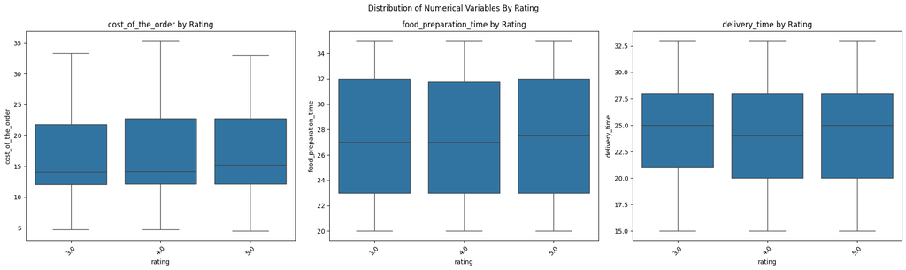

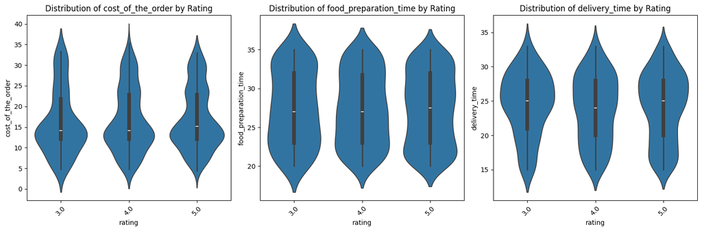

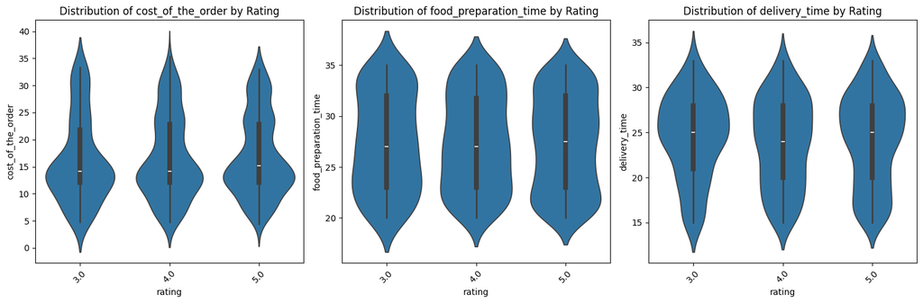

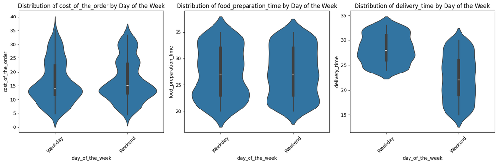

[output not shown]

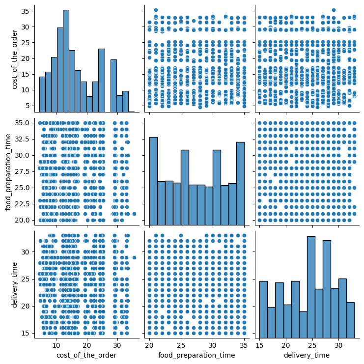

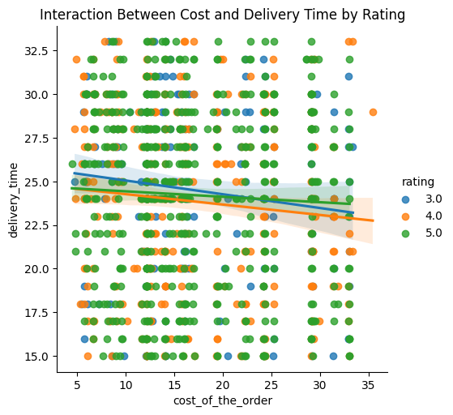

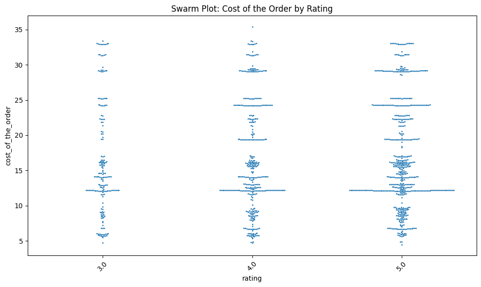

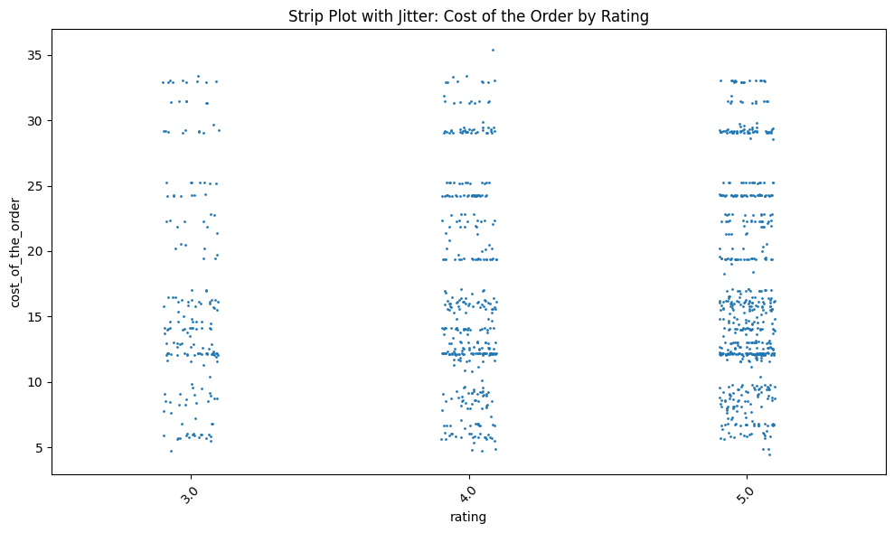

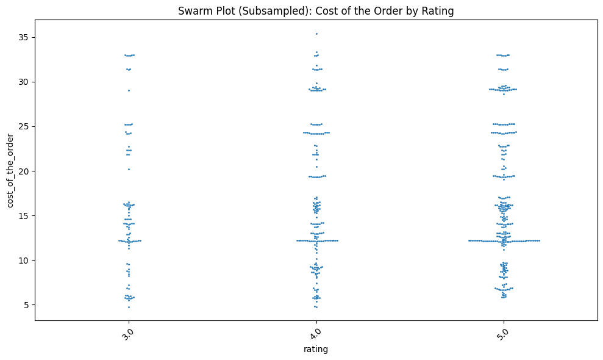

```python
from scipy import stats

# have the dataframe contain only numberical variables
numDf = df.select_dtypes(include = ['float64', 'int64'])

# correlation matrix
relationMatrix = numDf.corr()

# use heatMap
plt.figure(figsize = (10,8))
sns.heatmap(relationMatrix, annot = True, cmap = 'coolwarm')
plt.title('Correlation Matrix for Numerical Variables ')
plt.show()

# boxplot dif·fer·en·ti·ate 'cost of the order' 'delivery time' 'food preperation time'
num_vars = ['cost_of_the_order', 'food_preparation_time', 'delivery_time']
fig, axes = plt.subplots(1,3, figsize = (20, 6))
fig.suptitle('Distribution of Numerical Variables By Rating')

for i, var in enumerate(num_vars):
    sns.boxplot(x = 'rating', y = var, data = df, ax = axes[i])
    axes[i].set_title(f'{var} by Rating')
    axes[i].tick_params(axis = 'x', rotation =45)

plt.tight_layout()
plt.show()

# violin plot for better distribution
plt.figure(figsize = (15,5))
for i, var in enumerate(num_vars, 1):
    plt.subplot(1,3,i)
    sns.violinplot(x = 'rating', y = var, data = df)
    plt.title(f'Distribution of {var} by Rating')
    plt.xticks(rotation = 45)

plt.tight_layout()
plt.show()

#numerical vs caterorical using Violin plot by rating

plt.figure(figsize = (15,5))
for i, var in enumerate(num_vars, 1):
    plt.subplot(1,3,i)
    sns.violinplot(x ='rating', y = var, data =df)
    plt.title(f'Distribution of {var} by Rating')
    plt.xticks(rotation = 45)
plt.tight_layout()
plt.show()

for i , var in enumerate(num_vars):
    sns.boxplot(x = 'day_of_the_week', y= var, data = df, ax = axes[i])
    axes[i].set_title(f'{var} by Day of The Week')
    axes[i].tick_params(axis = 'x', rotation = 45)

plt.tight_layout()
plt.show()

# num vs caterogrical analysis : violin plot by day of the week

plt.figure(figsize =(15, 5))
for i, var in enumerate(num_vars, 1):
    plt.subplot(1,3,i)
    sns.violinplot(x = 'day_of_the_week', y = var, data = df)
    plt.title(f'Distribution of {var} by Day of the Week')
    plt.xticks(rotation = 45)
plt.tight_layout()
plt.show()

# stat analyssis

def analyze_relation(df,numerical_var, categorical_var = 'rating'):
    # group stats for each category

    groupStats = df.groupby(categorical_var)[numerical_var].agg(['mean', 'std', 'count'])

    # remove 'not given' category for test
    dfClean = df[df[categorical_var] != 'Not given']

    groups = [group for _, group in dfClean.groupby(categorical_var)[numerical_var]]
    f_stat, p_value = stats.f_oneway(*groups)

    print(f"\nAnalysis of {numerical_var} by {categorical_var}")
    print("\nGroup Statistics:")
    print(groupStats)
    print(f"\nOne-way ANOVA test results:")
    print(f"F-statistics: {f_stat:.4f}")
    print(f"p-value: {p_value:.4f}")


for var in num_vars:
    analyze_relation(df,var)


sns.pairplot(df[num_vars])
plt.show()


sns.lmplot(x = 'cost_of_the_order', y = 'delivery_time', hue = 'rating' , data = df)
plt.title('Interaction Between Cost and Delivery Time by Rating')
plt.show()

# Swarm Plot with smaller marker size
plt.figure(figsize=(10, 6))
sns.swarmplot(x='rating', y='cost_of_the_order', data=df, size=2)  # Reduced marker size
plt.title('Swarm Plot: Cost of the Order by Rating')
plt.xticks(rotation=45)
plt.tight_layout()
plt.show()

# Strip Plot with jitter and smaller marker size
plt.figure(figsize=(10, 6))
sns.stripplot(x='rating', y='cost_of_the_order', data=df, jitter=True, size=2)  # Jitter added and smaller marker size
plt.title('Strip Plot with Jitter: Cost of the Order by Rating')
plt.xticks(rotation=45)
plt.tight_layout()
plt.show()

# Subsample data (50% of the data) for Swarm Plot
df_sample = df.sample(frac=0.5, random_state=42)  # Random sample of 50% of data
plt.figure(figsize=(10, 6))
sns.swarmplot(x='rating', y='cost_of_the_order', data=df_sample, size=2)  # Reduced marker size for sample data
plt.title('Swarm Plot (Subsampled): Cost of the Order by Rating')
plt.xticks(rotation=45)
plt.tight_layout()
plt.show()
```

### **Question 13:** The company wants to provide a promotional offer in the advertisement of the restaurants. The condition to get the offer is that the restaurants must have a rating count of more than 50 and the average rating should be greater than 4. Find the restaurants fulfilling the criteria to get the promotional offer. [3 marks]

```python
#check n clean data
df['rating'] = pd.to_numeric(df['rating'], errors = 'coerce')

# check for NaN values in rating
nanCount= df['rating'].isna().sum()
print(f"Number of Nan Values in 'rating:{nanCount}")

# drop rows with Nan ratings if needed
df = df.dropna(subset = ['rating'])


# group by restaurant and calculate the rating and average rating
restaurantStats = df.groupby('restaurant_name').agg(
    ratingCount = ('rating', 'count'),
    averageRating = ('rating', 'mean')

)

# filter restaurants that have mroe than 50 rating lvl and an average rating greater than 4
promotionalRestaurants = restaurantStats[(restaurantStats['ratingCount'] > 50 ) & (restaurantStats['averageRating'] > 4)]

# display the result
print(promotionalRestaurants)
```

```
Number of Nan Values in 'rating:736
                           ratingCount  averageRating
restaurant_name
Blue Ribbon Fried Chicken           64       4.328125
Blue Ribbon Sushi                   73       4.219178
Shake Shack                        133       4.278195
The Meatball Shop                   84       4.511905
```

### **Question 14:** The company charges the restaurant 25% on the orders having cost greater than 20 dollars and 15% on the orders having cost greater than 5 dollars. Find the net revenue generated by the company across all orders. [3 marks]

```python
 #define condition for the revenue calculation

def calculateRevenue(cost):
    if cost > 20:
        return cost * 0.25
    elif cost > 5:
        return cost * 0.15
    else:
        return 0

# apply the function to calculate revenue for each order
df['revenue'] = df['cost_of_the_order'].apply(calculateRevenue)



# calculate the total revenue generated by the company
totalRevenue = df['revenue'].sum()

#display the taol revenue
print(f'Total Revenue generated by the company: ${totalRevenue:.2f}')
```

[output not shown]

#### Observations:it is counterproductive for the company to offer anything less than five dollars. The company gets 0 revenue for five dollar orders. nothing on the app should be less than 5 dollars. If they need a beverage force them to buy a combination meal deal or a bundle of some kind.

### **Question 15:** The company wants to analyze the total time required to deliver the food. What percentage of orders take more than 60 minutes to get delivered from the time the order is placed? (The food has to be prepared and then delivered.) [2 marks]

```python
# calculate the overall time (food prep + deleivery time)
df['totalDeliveryTime'] = df['food_preparation_time'] + df['delivery_time']

# sift the orders bases on total delivery time that is great than 60 minutes
orderOver60Minutes = df[df['totalDeliveryTime'] > 60]

percentageOver60 = (len(orderOver60Minutes) / len(df)) * 100

# display
print(f'Percentage of orders taking more than 60 minutes to deliver: \n{percentageOver60:.2f}%')
#Percentage of orders taking more than 60 minutes to deliver:
#10.23%
```

```
Percentage of orders taking more than 60 minutes to deliver:
10.24%
```

#### Observations: if the only 10% take 60 minutes to deliver. 35 % promotional to customer only if it exceeds 40 dollars. give a 15 % driver because it a long drive time. Need an incentive to get a driver to go out there . or require tip amount for driver

### **Question 16:** The company wants to analyze the delivery time of the orders on weekdays and weekends. How does the mean delivery time vary during weekdays and weekends? [2 marks]

```python
# group by 'day of the week ' calculate mean delivery time for each group
meanDeliveryTime = df.groupby('day_of_the_week')['delivery_time'].mean()

# Display the results with proper syntax
print(f"Mean delivery time on weekdays: {meanDeliveryTime.get('Weekday', 'Data not available'):.2f} minutes")
print(f"Mean delivery time on weekends: {meanDeliveryTime.get('Weekend', 'Data not available'):.2f} minutes")
```

```
Mean delivery time on weekdays: 28.31 minutes
Mean delivery time on weekends: 22.44 minutes
```

#### Observations: from the data, because of traffic, their is a longer wait time for delivery on weekdays.

### Conclusion and Recommendations

### **Question 17:** What are your conclusions from the analysis? What recommendations would you like to share to help improve the business? (You can use cuisine type and feedback ratings to drive your business recommendations.) [6 marks]

### Conclusions: The company has a solid business model and a well-structured dataset. However, some of the data, such as customer ratings, is incomplete or inconclusive due to missing feedback from several customers. While the company receives mostly positive reviews, customer satisfaction is mixed, as not all customers provided feedback. The most frequently ordered cuisines are American and Japanese, indicating strong customer preference for these types of meals.

### Recommendations:I wanted to share some recommendations that I believe could greatly benefit the company.my first recommendation is to enhance the collection of customer feedback would provide us with more better insights. To achieve this, I suggest implementing a rewards program to encourage customers to provide more detailed feedback. Once we have gathered more responses, we can assess the lowest-rated restaurants and decide whether to replace them with higher-rated alternatives or adjust their pricing strategies to improve their performance. I would recommend , establishing a system threshold to flag restaurants with consistently poor reviews or low ratings would allow us to address issues more effeciently. The next recommendation is to focus on attracting customers to order from lower-rated cuisines. This could be accomplished through weekly promotional offers on selected dishes or by highlighting special events. I believe this would attract more eyes on the restaurants. We could also partner with specific restaurants to promote their offerings and diversify the order base.I would also recommend optimizing both food preparation and delivery times. Reducing wait times will help improve the customer experience and ensure that both our customers and staff remain happy and efficient.My last recommentation in regard to our top-performing partners, I believe we should consider adjusting our revenue-sharing model. Taking less revenue from the highest-earning cuisines or restaurants could help strengthen those relationships and ensure long-term business success with our best-performing partners.